# Notes: Bioconductor for Genomic Data Science

### GenomicRanges: _Lists

We’ve already come across these xxLists (where ‘xx’ is some class) earlier, like ‘RleList’. They’re basically similar to a normal list in R.

I was reading the [lecture notes](http://kasperdanielhansen.github.io/genbioconductor/html/GenomicRanges_Lists.html) provided by the lecturer and this is just soo extremely funny lolol:

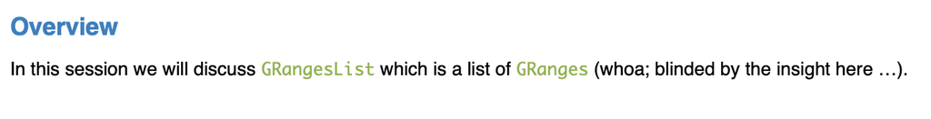

#### GRangesList

An important usecase specifically for GRangesList is the representation of a set of transcripts. Each transcript is an element in the GRangesList and the exons of the transcript is represented as a GRanges (in which each exon is a range).

```r
gL <- GRangesList(gr1 = gr, gr2 = gr3)
gL
```

```
## GRangesList object of length 2:
## $gr1
## GRanges object with 4 ranges and 2 metadata columns:
##       seqnames    ranges strand |     score    score2
##          <Rle> <IRanges>  <Rle> | <numeric> <numeric>
##   [1]     chr1       1-3      + |  1.317432 0.0658716
##   [2]     chr2       1-3      - |  0.429204 0.0214602
##   [3]     chr1       5-7      + |  2.793774 0.1396887
##   [4]     chr2       3-5      * |  0.478792 0.0239396
##   -------
##   seqinfo: 2 sequences from hg19 genome
##
## $gr2
## GRanges object with 4 ranges and 2 metadata columns:
##       seqnames    ranges strand |     score    score2
##          <Rle> <IRanges>  <Rle> | <numeric> <numeric>
##   [1]     chr1       1-3      * |        NA        NA
##   [2]     chr1       2-4      * |        NA        NA
##   [3]     chr1       3-5      - |        NA        NA
##   [4]     chr1       4-6      + |        NA        NA
##   -------
##   seqinfo: 2 sequences from hg19 genome
```

```r
# A number of standard GRanges functions work, but returns other_classLists
start(gL)
```

```
## IntegerList of length 2
## [["gr1"]] 1 1 5 3
## [["gr2"]] 1 2 3 4
```

```r
seqnames(gL)
```

```
## RleList of length 2
## $gr1
## factor-Rle of length 4 with 4 runs
##   Lengths:    1    1    1    1
##   Values : chr1 chr2 chr1 chr2
## Levels(2): chr2 chr1
##
## $gr2
## factor-Rle of length 4 with 1 run
##   Lengths:    4
##   Values : chr1
## Levels(2): chr2 chr1
```

```r
# elementLengths(gL) # This is equivalent to sapply(gL, length) which is slow in comparison; raises an error: Error in elementLengths(gL) : could not find function "elementLengths"
shift(gL, 10)
```

```
## GRangesList object of length 2:
## $gr1
## GRanges object with 4 ranges and 2 metadata columns:
##       seqnames    ranges strand |     score    score2
##          <Rle> <IRanges>  <Rle> | <numeric> <numeric>
##   [1]     chr1     11-13      + |  1.317432 0.0658716
##   [2]     chr2     11-13      - |  0.429204 0.0214602
##   [3]     chr1     15-17      + |  2.793774 0.1396887
##   [4]     chr2     13-15      * |  0.478792 0.0239396
##   -------
##   seqinfo: 2 sequences from hg19 genome
##
## $gr2
## GRanges object with 4 ranges and 2 metadata columns:
##       seqnames    ranges strand |     score    score2
##          <Rle> <IRanges>  <Rle> | <numeric> <numeric>
##   [1]     chr1     11-13      * |        NA        NA
##   [2]     chr1     12-14      * |        NA        NA
##   [3]     chr1     13-15      - |        NA        NA
##   [4]     chr1     14-16      + |        NA        NA
##   -------
##   seqinfo: 2 sequences from hg19 genome
```

`findOverlaps` for GRangesLists considers each element as a union of ranges, so we get an overlap if *any range in the list* overlaps, but the ‘Hits’ returned (see below, only 1 and 2) are only the indices for the GRangesLists elements.

```r
findOverlaps(gL, gr3)
```

```
## Hits object with 7 hits and 0 metadata columns:
##       queryHits subjectHits
##       <integer>   <integer>
##   [1]         1           1
##   [2]         1           2
##   [3]         1           4
##   [4]         2           1
##   [5]         2           2
##   [6]         2           3
##   [7]         2           4
##   -------
##   queryLength: 2 / subjectLength: 4
```

### GenomicFeatures and TxDb

The GenomicFeatures package contains functionality for **transcript database or TxDb objects**. ‘tx’ under this context all refers to transcript.

#### TxDb objects

Extract basic quantities: `genes()`, `transcripts()`, `cds()`, `exons()`, `microRNAs()`, `tRNAs()`, `promoters()`. We can extract quantities and groups by using `_By()` functions eg. `transcriptsBy(by = c("gene", "exon", "cds"))`

```r
library(TxDb.Hsapiens.UCSC.hg19.knownGene)
txdb <- TxDb.Hsapiens.UCSC.hg19.knownGene
txdb
```

```
## TxDb object:
## # Db type: TxDb
## # Supporting package: GenomicFeatures
## # Data source: UCSC
## # Genome: hg19
## # Organism: Homo sapiens
## # Taxonomy ID: 9606
## # UCSC Table: knownGene
## # Resource URL: http://genome.ucsc.edu/
## # Type of Gene ID: Entrez Gene ID
## # Full dataset: yes
## # miRBase build ID: GRCh37
## # transcript_nrow: 82960
## # exon_nrow: 289969
## # cds_nrow: 237533
## # Db created by: GenomicFeatures package from Bioconductor
## # Creation time: 2015-10-07 18:11:28 +0000 (Wed, 07 Oct 2015)
## # GenomicFeatures version at creation time: 1.21.30
## # RSQLite version at creation time: 1.0.0
## # DBSCHEMAVERSION: 1.1
```

```r
genes(txdb)
```

```
##   403 genes were dropped because they have exons located on both strands of the
##   same reference sequence or on more than one reference sequence, so cannot be
##   represented by a single genomic range.
##   Use 'single.strand.genes.only=FALSE' to get all the genes in a GRangesList
##   object, or use suppressMessages() to suppress this message.
```

```
## GRanges object with 23056 ranges and 1 metadata column:
##         seqnames              ranges strand |     gene_id
##            <Rle>           <IRanges>  <Rle> | <character>
##       1    chr19   58858172-58874214      - |           1
##      10     chr8   18248755-18258723      + |          10
##     100    chr20   43248163-43280376      - |         100
##    1000    chr18   25530930-25757445      - |        1000
##   10000     chr1 243651535-244006886      - |       10000
##     ...      ...                 ...    ... .         ...
##    9991     chr9 114979995-115095944      - |        9991
##    9992    chr21   35736323-35743440      + |        9992
##    9993    chr22   19023795-19109967      - |        9993
##    9994     chr6   90539619-90584155      + |        9994
##    9997    chr22   50961997-50964905      - |        9997
##   -------
##   seqinfo: 93 sequences (1 circular) from hg19 genome
```

```r
gr <- GRanges(seqnames = "chr1", strand = "+", ranges = IRanges(start = 11874, end = 14409))
subsetByOverlaps(exons(txdb), gr)
```

```
## GRanges object with 6 ranges and 1 metadata column:
##       seqnames      ranges strand |   exon_id
##          <Rle>   <IRanges>  <Rle> | <integer>
##   [1]     chr1 11874-12227      + |         1
##   [2]     chr1 12595-12721      + |         2
##   [3]     chr1 12613-12721      + |         3
##   [4]     chr1 12646-12697      + |         4
##   [5]     chr1 13221-14409      + |         5
##   [6]     chr1 13403-14409      + |         6
##   -------
##   seqinfo: 93 sequences (1 circular) from hg19 genome
```

```r
# Recall that GRangesList effectively represents a set of transcripts
subsetByOverlaps(exonsBy(txdb, by = "tx"), gr)
```

```
## GRangesList object of length 3:
## $`1`
## GRanges object with 3 ranges and 3 metadata columns:
##       seqnames      ranges strand |   exon_id   exon_name exon_rank
##          <Rle>   <IRanges>  <Rle> | <integer> <character> <integer>
##   [1]     chr1 11874-12227      + |         1        <NA>         1
##   [2]     chr1 12613-12721      + |         3        <NA>         2
##   [3]     chr1 13221-14409      + |         5        <NA>         3
##   -------
##   seqinfo: 93 sequences (1 circular) from hg19 genome
##
## $`2`
## GRanges object with 3 ranges and 3 metadata columns:
##       seqnames      ranges strand |   exon_id   exon_name exon_rank
##          <Rle>   <IRanges>  <Rle> | <integer> <character> <integer>
##   [1]     chr1 11874-12227      + |         1        <NA>         1
##   [2]     chr1 12595-12721      + |         2        <NA>         2
##   [3]     chr1 13403-14409      + |         6        <NA>         3
##   -------
##   seqinfo: 93 sequences (1 circular) from hg19 genome
##
## $`3`
## GRanges object with 3 ranges and 3 metadata columns:
##       seqnames      ranges strand |   exon_id   exon_name exon_rank
##          <Rle>   <IRanges>  <Rle> | <integer> <character> <integer>
##   [1]     chr1 11874-12227      + |         1        <NA>         1
##   [2]     chr1 12646-12697      + |         4        <NA>         2
##   [3]     chr1 13221-14409      + |         5        <NA>         3
##   -------
##   seqinfo: 93 sequences (1 circular) from hg19 genome
```

### rtracklayer and importing data

The rtracklayer package contains functions for **importing and exporting data** to (UCSC) Genome Browser. This includes functionality for parsing file formats associated with the browser such as BED, Wig, BigBed and BigWig.

A Wig file is a representation of signals/numeric quantity along the genome. BigWig contains a single vector across the entire genome, but it’s compressed and easy to extract the values for a given region. One way to get a BigWig file is by using AnnotationHub.

It took too long, so i won’t run it again…

```r
table(ah$rdataclass)
# For those that `rdataclass == "GRanges"`, they are usually directly constructed from BED files with the seqinfo information fully populated.
# But we'll look at BigWig files rn.
ah.bw <- subset(ah, rdataclass == "BigWigFile" & species == "Homo sapiens")
ah.bw
bw <- ah.bw[[1]]
bw
```

When we retrieve it we get a file name, **ready for use by `import()` to read the data into our memory**. The `format` argument specifies the format type (“BigWig” or “BED”) and `which` is like filtering the BigWig by a specified GRanges. The output data type is a GRanges per default, but using the `as` argument we can have as=“Rle” and a few other options.

The `import` failed when I was actually running the former code chunk and this one: “UCSC library operation failed.”

```r
gr.chr22 = import(bw, which=GRanges("chr22", ranges=IRanges(1,10^8)))
gr.chr22
gr.rle = import(bw, which=GRanges("chr22", ranges=IRanges(1,10^8)), as="Rle")
```

`liftOver()` function in the rtracklayer package allows us to convert between different genomes (eg. hg19 <-> hg18). We’ll need the ‘chain’ file describing the conversion.

```r
ah.chain <- subset(ah, rdataclass == "ChainFile" & species == "Homo sapiens")
query(ah.chain, c("hg18", "hg19"))
chain <- ah.chain[ah.chain$title == "hg19ToHg18.over.chain.gz"]
chain <- chain["hg19ToHg18.over.chain.gz"]
gr.hg18 <- liftOver(gr, chain)
gr.hg18
```

This converts a GRanges into a GRangesList because a single range may be split into multiple intervals in the other genome.

## Representing data in Bioconductor

- **Basic data types: experimental data, metadata, annotation**.
  - Annotating is the process of giving context to experimental data using external information, usually thought as linking our experimental data to various online databases.
- Raw data (unprocessed) -> pre-processed data -> results through statistical analysis.

**Data container**: after we obtained raw data from various means, we preprocess it according to the specific way it was obtained (eg. the sequencing technology/instrument). Then we put the pre-processed data into a common data container, which would make analysis a lot easier.

### ExpressionSet

One of the most important data containers in Bioconductor for representing an expression experiment (eg. RNA-seq). In context of the ‘basic data types’:

- We think of the **expression matrix** as really *raw experimental data* (note that, the representation of this matrix is very different (feels like it’s transposed) from other tabular data like design matrices), the **phenotype data** and the **feature data** are *metadata* on the experiment. All these three dataframes or matrices fit together into something we call an ExpressionSet (**these are the *three essential matrices* in bioinformatics**). When we have multiple expression matrices, it’s called an **eSet**. This can be useful for representing experiments where there are multiple channels, etc.

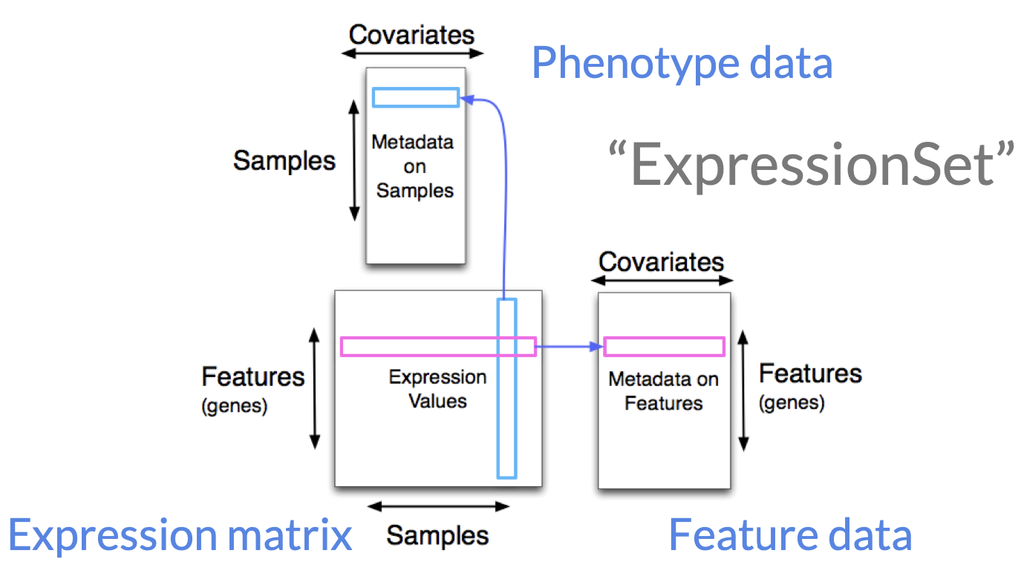

An example of an ExpressionSet object is the `ALL` **experiment package** that **contains a dataset for an experiment**, accessed by `data(ALL)` after it’s imported. The core of the ExpressionSet object are two matrices:

- The `exprs` matrix (the expression matrix) containing the 12625 gene expression measurements on the 128 samples (a 12625 by 128 numeric matrix). To subset, simply use `exprs(ALL)[1:4, 1:4]`.
  - Note that if you subset the *ExperimentSet* itself rather than the expression *matrix* via `ALL[1:4, 1:4]`, it will still return an ExperimentSet object.
- The `pData` data.frame containing *phenotype data* on the samples. Similar to any other data.frame, we can access individual columns of the `pData` df using the `$` operator. Alongside phenotype data (which is info on the samples), we can also access the feature data (info on the features/genes).

### SummarizedExperiment

Similar to the `ALL` dataset for an ExperimentSet, for illustration here we use another example dataset for an RNA-seq experiment stored in the `airway` package.

- **Metadata: `colData` contains phenotype (sample) information, like `pData` for ExpressionSet. It returns a capital DataFrame instead of a classical data.frame. `rowData` contains info about features eg. genes.**
- The measurement matrices (basically the same as expression matrices but broader) are accessed by `assay` and `assays`. A SummarizedExperiment can contain multiple measurement matrices (all of the same dimension). We get all of them by `assays` and a single one by `assay(object, assay_name)` where we can see the names after printing the object or by using `assayNames`.

```r
library(GenomicRanges)
library(airway)
data(airway)
airway
```

```
## class: RangedSummarizedExperiment
## dim: 63677 8
## metadata(1): ''
## assays(1): counts
## rownames(63677): ENSG00000000003 ENSG00000000005 ... ENSG00000273492
##   ENSG00000273493
## rowData names(10): gene_id gene_name ... seq_coord_system symbol
## colnames(8): SRR1039508 SRR1039509 ... SRR1039520 SRR1039521
## colData names(9): SampleName cell ... Sample BioSample
```

```r
rowData(airway)
```

```
## DataFrame with 63677 rows and 10 columns
##                         gene_id     gene_name  entrezid   gene_biotype
##                     <character>   <character> <integer>    <character>
## ENSG00000000003 ENSG00000000003        TSPAN6        NA protein_coding
## ENSG00000000005 ENSG00000000005          TNMD        NA protein_coding
## ENSG00000000419 ENSG00000000419          DPM1        NA protein_coding
## ENSG00000000457 ENSG00000000457         SCYL3        NA protein_coding
## ENSG00000000460 ENSG00000000460      C1orf112        NA protein_coding
## ...                         ...           ...       ...            ...
## ENSG00000273489 ENSG00000273489 RP11-180C16.1        NA      antisense
## ENSG00000273490 ENSG00000273490        TSEN34        NA protein_coding
## ENSG00000273491 ENSG00000273491  RP11-138A9.2        NA        lincRNA
## ENSG00000273492 ENSG00000273492    AP000230.1        NA        lincRNA
## ENSG00000273493 ENSG00000273493  RP11-80H18.4        NA        lincRNA
##                 gene_seq_start gene_seq_end              seq_name seq_strand
##                      <integer>    <integer>           <character>  <integer>
## ENSG00000000003       99883667     99894988                     X         -1
## ENSG00000000005       99839799     99854882                     X          1
## ENSG00000000419       49551404     49575092                    20         -1
## ENSG00000000457      169818772    169863408                     1         -1
## ENSG00000000460      169631245    169823221                     1          1
## ...                        ...          ...                   ...        ...
## ENSG00000273489      131178723    131182453                     7         -1
## ENSG00000273490       54693789     54697585 HSCHR19LRC_LRC_J_CTG1          1
## ENSG00000273491      130600118    130603315          HG1308_PATCH          1
## ENSG00000273492       27543189     27589700                    21          1
## ENSG00000273493       58315692     58315845                     3          1
##                 seq_coord_system        symbol
##                        <integer>   <character>
## ENSG00000000003               NA        TSPAN6
## ENSG00000000005               NA          TNMD
## ENSG00000000419               NA          DPM1
## ENSG00000000457               NA         SCYL3
## ENSG00000000460               NA      C1orf112
## ...                          ...           ...
## ENSG00000273489               NA RP11-180C16.1
## ENSG00000273490               NA        TSEN34
## ENSG00000273491               NA  RP11-138A9.2
## ENSG00000273492               NA    AP000230.1
## ENSG00000273493               NA  RP11-80H18.4
```

```r
assays(airway)
```

```
## List of length 1
## names(1): counts
```

```r
head(assay(airway, "counts"))
```

```
##                 SRR1039508 SRR1039509 SRR1039512 SRR1039513 SRR1039516
## ENSG00000000003        679        448        873        408       1138
## ENSG00000000005          0          0          0          0          0
## ENSG00000000419        467        515        621        365        587
## ENSG00000000457        260        211        263        164        245
## ENSG00000000460         60         55         40         35         78
## ENSG00000000938          0          0          2          0          1
##                 SRR1039517 SRR1039520 SRR1039521
## ENSG00000000003       1047        770        572
## ENSG00000000005          0          0          0
## ENSG00000000419        799        417        508
## ENSG00000000457        331        233        229
## ENSG00000000460         63         76         60
## ENSG00000000938          0          0          0
```

The new thing is that SummarizedExperiment allows for the `rowRanges` (or accessed by `GRanges`) data representing the different features. It returns a GRangesList, with **every element of the list (a GRanges object) being a feature (a gene) and every range inside the feature being an exon)**.

Since these are (or contain) GRanges we can basically do all the corresponding operations on them.

```r
rowRanges(airway)
```

```
## GRangesList object of length 63677:
## $ENSG00000000003
## GRanges object with 17 ranges and 2 metadata columns:
##        seqnames            ranges strand |   exon_id       exon_name
##           <Rle>         <IRanges>  <Rle> | <integer>     <character>
##    [1]        X 99883667-99884983      - |    667145 ENSE00001459322
##    [2]        X 99885756-99885863      - |    667146 ENSE00000868868
##    [3]        X 99887482-99887565      - |    667147 ENSE00000401072
##    [4]        X 99887538-99887565      - |    667148 ENSE00001849132
##    [5]        X 99888402-99888536      - |    667149 ENSE00003554016
##    ...      ...               ...    ... .       ...             ...
##   [13]        X 99890555-99890743      - |    667156 ENSE00003512331
##   [14]        X 99891188-99891686      - |    667158 ENSE00001886883
##   [15]        X 99891605-99891803      - |    667159 ENSE00001855382
##   [16]        X 99891790-99892101      - |    667160 ENSE00001863395
##   [17]        X 99894942-99894988      - |    667161 ENSE00001828996
##   -------
##   seqinfo: 722 sequences (1 circular) from an unspecified genome
##
## ...
## <63676 more elements>
```

```r
start(airway)
```

```
## IntegerList of length 63677
## [["ENSG00000000003"]] 99883667 99885756 99887482 ... 99891605 99891790 99894942
## [["ENSG00000000005"]] 99839799 99840228 99848621 ... 99852501 99854013 99854505
## [["ENSG00000000419"]] 49551404 49551404 49551433 ... 49574900 49574900 49574900
## [["ENSG00000000457"]] 169818772 169821804 169822215 ... 169862929 169863148
## [["ENSG00000000460"]] 169631245 169652610 169652897 ... 169821931 169821931
## [["ENSG00000000938"]] 27938575 27938803 27938811 ... 27961576 27961576 27961576
## [["ENSG00000000971"]] 196621008 196621186 196621186 ... 196716241 196716241
## [["ENSG00000001036"]] 143815948 143817763 143818089 ... 143832548 143832548
## [["ENSG00000001084"]] 53362139 53362139 53362940 ... 53428915 53429548 53481684
## [["ENSG00000001167"]] 41040684 41040722 41046768 ... 41062135 41065096 41065096
## ...
## <63667 more elements>
```

```r
gr <- GRanges(seqnames = "1", ranges = IRanges(start = 1, end = 10^7))
subsetByOverlaps(airway, gr)
```

```
## class: RangedSummarizedExperiment
## dim: 329 8
## metadata(1): ''
## assays(1): counts
## rownames(329): ENSG00000007923 ENSG00000008128 ... ENSG00000272512
##   ENSG00000273443
## rowData names(10): gene_id gene_name ... seq_coord_system symbol
## colnames(8): SRR1039508 SRR1039509 ... SRR1039520 SRR1039521
## colData names(9): SampleName cell ... Sample BioSample
```

### GEOquery

NCBI Gene Expression Omnibus (GEO) is organised as **samples which are grouped into series**. For bigger experiments there are both SubSeries and SuperSeries. A SuperSeries is all the experiments for a single paper; a SuperSeries can be decomposed into SubSeries which are *different technologies*.

Data submitted to GEO can be both “raw” and “processed”.

- For gene expression data, **processed** data is normalized and quantified, typically at the gene level, and is usually provided in the form of a gene by sample matrix.
- **Raw** data can be anything, from sequencing reads to microarray image files, eg. for a RNA-seq dataset you may even have *different states* of “raw” data: FASTQ files (raw reads), BAM files (aligned reads), gene by sample expression matrix (unnormalized) and gene by sample expression matrix (normalized).

GEO has series identifiers (like GSE19486, aka accession number) and sample identiers (GSM486297). A user is almost always interested in all the samples in a given series, so we start by downloading data from GEO using an accession number.

This runs for too long… shouldn’t let it knit

```r
library(GEOquery)
eList <- getGEO("GSE11675")
class(eList) # It returns a list since we might get multiple SubSeries where each element is an ExpressionSet.
eData <- eList[[1]]
eData
```

However, what we got here (by `getGEO(GEO_accession_number)`) was processed data. Users often want access to more raw data. This is called “*supplementary files*” in GEO terms and `getGEOSuppFiles(GEO_accession_number)` goes online and gets it for us.

### biomaRt

“Biomart” is a flexible **interface** to a biological database (kinda like AnnotationHub) and then to multiple datasets inside the database (aka the **mart**).

There is one main function for **querying** in the package biomaRt: `getBM()` (get Biomart). It retrives data from a Biomart based on this query, which consists of 3 things: “attributes” (eg. gene names), “filters” and “values” (actual values of the assigned “filters”). A major part of using biomaRt is figuring out which attributes and which filters to use. We can get a description of this using `listAttributes()` and `listFilters()`.

### The S4 System

NOTE THAT in R, **S4 classes and S4 methods are completely separated concepts** unlike the relationship between methods and classes in other object-oriented programming languages (eg. Java and Python).

S3, S4, S5, etc. are just multiple object-oriented programming (OOP) systems that we can choose from in R.

#### S4 classes

S4 classes provides a way of representing complicated data structures that also link between different data structures. We have used this a lot already, eg. ExpressionSets and SummarizedExperiments.

In Base R (which mainly uses *the S3 system*), we can make any object into any class. However, an S3 object is essentially a list **with a class attribute on it** (`class()` for getting/setting), which means **we can assign any class to any list, which is nonsense**.

S4 classes have a formal definition and formal validity checking. To the end user, this guarantees **validity of the object** instead of some weird nonsense list that does not look like other objects of the same class at all (as in S3).

```r
class(airway)
```

```
## [1] "RangedSummarizedExperiment"
## attr(,"package")
## [1] "SummarizedExperiment"
```

```r
isS4(airway)
```

```
## [1] TRUE
```

```r
# Get help (also returns the help page for the constructor function since their names are the same)
?SummarizedExperiment
class?SummarizedExperiment
getClass("SummarizedExperiment")
```

```
## Class "SummarizedExperiment" [package "SummarizedExperiment"]
##
## Slots:
##
## Name:            colData            assays             NAMES   elementMetadata
## Class:         DataFrame    Assays_OR_NULL character_OR_NULL         DataFrame
##
## Name:           metadata
## Class:              list
##
## Extends:
## Class "RectangularData", directly
## Class "Vector", directly
## Class "Annotated", by class "Vector", distance 2
## Class "vector_OR_Vector", by class "Vector", distance 2
##
## Known Subclasses:
## Class "RangedSummarizedExperiment", directly, with explicit coerce
```

**Data inside an S4 class are organized into slots. We access slots by using either ‘@’ or the `slots()`**. Although the `@` operation is the way to access (and extract) data in the course I was having to deal with TCGA, it is recommended that as a user we should use the accessor functions eg. `assays(airway)` rather than directly accessing like `airway@assays`.

```r
airway@assays
```

```
## An object of class "SimpleAssays"
## Slot "data":
## List of length 1
## names(1): counts
```

```r
assays(airway)
```

```
## List of length 1
## names(1): counts
```

```r
head(assay(airway, "counts")) # recall, assay(object, "name")
```

```
##                 SRR1039508 SRR1039509 SRR1039512 SRR1039513 SRR1039516
## ENSG00000000003        679        448        873        408       1138
## ENSG00000000005          0          0          0          0          0
## ENSG00000000419        467        515        621        365        587
## ENSG00000000457        260        211        263        164        245
## ENSG00000000460         60         55         40         35         78
## ENSG00000000938          0          0          2          0          1
##                 SRR1039517 SRR1039520 SRR1039521
## ENSG00000000003       1047        770        572
## ENSG00000000005          0          0          0
## ENSG00000000419        799        417        508
## ENSG00000000457        331        233        229
## ENSG00000000460         63         76         60
## ENSG00000000938          0          0          0
```

Class inheritance is used when you define a new class which “is almost like this other class but with a little twist”. Eg. ExpressionSet inherits from eSet (it “twists” by adding a single `exprs()` accessor function for the `@experimentData` slot in the class), and RangedSummarizedExperiment inherits from SummarizedExperiment (as shown under “Known Subclasses” above).

#### S4 methods

We can think of a S4 method as a simple function but **can look at its arguments and decide what to do accordingly**. One way to mimic a method is by a function definition like the following:

```r
mimicMethod <- function(x) {
    if (is(x, "matrix"))
        method1(x)
    if (is(x, "data.frame"))
        method2(x)
    if (is(x, "IRanges"))
        method3(x)
}
```

Eg. `as.data.frame` redefined from the BiocGenerics package:

```r
base::as.data.frame # The original Base R function rather than the redirected/masked one.
```

```
## function (x, row.names = NULL, optional = FALSE, ...)
## {
##     if (is.null(x))
##         return(as.data.frame(list()))
##     UseMethod("as.data.frame")
## }
## <bytecode: 0x14ab695b0>
## <environment: namespace:base>
```

```r
showMethods("as.data.frame") # Shows the different values of input it can take, called "signatures"
```

```
## Function: as.data.frame (package BiocGenerics)
## x="ANY"
## x="Array"
## x="AsIs"
##     (inherited from: x="ANY")
## x="Bimap"
## x="BSgenomeViews"
## x="character"
##     (inherited from: x="ANY")
## x="DataFrame"
## x="DFrame"
##     (inherited from: x="DataFrame")
## x="factor"
##     (inherited from: x="ANY")
## x="GAlignmentPairs"
## x="GAlignments"
## x="GenomicRanges"
## x="GPos"
## x="GroupedIRanges"
## x="Hits"
## x="IPos"
## x="IPosRanges"
## x="List"
## x="logical"
##     (inherited from: x="ANY")
## x="OverlapEncodings"
## x="Pairs"
## x="Rle"
## x="Seqinfo"
## x="Vector"
## x="XStringSet"
## x="XStringViews"
```

```r
getMethod(f = "as.data.frame", signature = "DataFrame") # Shows the actual method for the specified input type/signature
```

```
## Method Definition:
##
## function (x, row.names = NULL, optional = FALSE, ...)
## {
##     .local <- function (x, row.names = NULL, optional = FALSE,
##         make.names = TRUE, ..., stringsAsFactors = FALSE)
##     {
##         if (!isTRUEorFALSE(make.names))
##             stop("'make.names' must be TRUE or FALSE")
##         if (length(list(...)))
##             warning("arguments in '...' ignored")
##         if (!identical(stringsAsFactors, FALSE))
##             stop("'stringsAsFactors' not supported")
##         if (is.null(row.names)) {
##             row.names <- rownames(x)
##             if (is.null(row.names)) {
##                 if (ncol(x) == 0L)
##                   row.names <- seq_len(nrow(x))
##             }
##             else {
##                 if (make.names)
##                   row.names <- make.unique(row.names)
##             }
##         }
##         else {
##             row.names <- as.character(row.names)
##             if (make.names)
##                 row.names <- make.names(row.names, unique = TRUE)
##             if (length(row.names) != nrow(x))
##                 stop("row names supplied are of the wrong length")
##         }
##         old_option <- getOption("stringsAsFactors")
##         options(stringsAsFactors = FALSE)
##         on.exit(options(stringsAsFactors = old_option))
##         x_colnames <- colnames(x)
##         df_list <- lapply(setNames(seq_along(x), x_colnames),
##             function(j) {
##                 col <- x[[j]]
##                 if (is.data.frame(col))
##                   return(col)
```

[output cut: 12 more lines]

```
##                   colnames(df) <- x_colnames[[j]]
##                 df
##             })
##         do.call(data.frame, c(df_list, list(row.names = row.names,
##             check.names = !optional, stringsAsFactors = FALSE)))
##     }
##     .local(x, row.names, optional, ...)
## }
## <bytecode: 0x11c355ad8>
## <environment: namespace:S4Vectors>
##
## Signatures:
##         x
## target  "DataFrame"
## defined "DataFrame"
```

## Getting data into Bioconductor

We’ve seen these convenient data containers like SummarizedExperiment, but how do we actually get our data in there?

The answer really depends on the file format…

> Bioinformatics has jokingly been referred to as “The Science of Inventing New File Formats”.

### ShortRead

A package that contains functionality for reading and examining raw sequence reads (typically in FASTQ format). One of the first Bioconductor packages to deal with *low-level* analysis of high-throughput sequencing data.

`readFastq()` returns a ShortReadQ object. The `ShortReadQ` class is very similar to a DNAStringSet but it has two sets of strings: **one for the read nucleotides and one for the base qualities**.

- ShortRead helps convert the quality scores (i.e. the fourth line of the FASTQ format) to the corresponding integer by eg. `as(quality(reads), "matrix")[1:2,1:10]`. Recall this `as(object, Class)` versatile conversion function from the methods package!

#### Rsamtools

Recall what we’ve learned from Course 4!! SAM/BAM formats represent the reads after they are aligned to the reference genome.

A BAM file can be sorted in multiple ways; if it is sorted according to genomic location, and then if it is also “indexed”, it is possible (and can be very useful) to retrieve all reads mapping to a genomic location. In Rsamtools this is done by the functions `sortBam()` and `indexBam()`.

To read a BAM file, **we must first set up a `BamFile` object to create a pointer to the file**. Then we read the reads using `scanBam()`.

- We can use `yieldSize(BamFile_object) <- number` to specify the number of alignments per `scanBam()`.
- We can also use `ScanBamParams()` to select certain reads based on the `which` argument for specified genomic regions (via specifying GRanges) and the `what` argument.

### Quick skim: microarray data

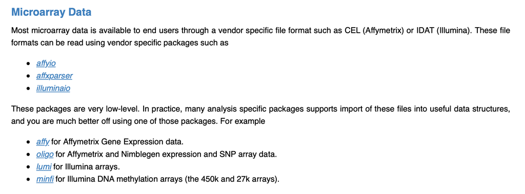

Screenshot from course Github page

I also skipped the two lectures on oligo and minfi T_T.